# Network inference with FlashWeave

Author

Mariam Rahali Masbouri

Published

March 24, 2026

In this file, we will perform network inference on the gut microbiota datasets using three different methods: LIMITS, FlashWeave and BEEM-Static. We will first import the relevant datasets from the dysbiotic cohorts (that is, those pertaining to IBD, IBS, CRC, and CDI) as well as the healthy cohorts from the Human Microbiome Project (HMPv13 and HMPv35), NIBIOHN and MORINAGA cohorts, and a “diet intervention” cohort as well. We describe first each tool and its implementation in the following sections, and then we will compare the results obtained from each method in a final section.

> TODO: Modify description

# 1 Importing the MAE object

```r
mae_file <-
  fs::dir_ls(str_c(data_dir(), "/02-processed-data"), regexp = "MAE_processed_.*\\.rds$") |>
  sort(decreasing = TRUE) |>
  magrittr::extract(1)


cat(str_c("Loading MultiAssayExperiment from: 00_data/", mae_file |> str_remove(data_dir()), "\n"))
```

```
Loading MultiAssayExperiment from: 00_data//02-processed-data/MAE_processed_20260321.rds
```

```r
mae <- readRDS(mae_file)

rm(mae_file)

mae
```

```
A MultiAssayExperiment object of 9 listed
 experiments with user-defined names and respective classes.
 Containing an ExperimentList class object of length 9:
 [1] IBD: SummarizedExperiment with 432 rows and 1630 columns
 [2] IBS: SummarizedExperiment with 598 rows and 62 columns
 [3] CDI: SummarizedExperiment with 868 rows and 366 columns
 [4] CRC: SummarizedExperiment with 837 rows and 575 columns
 [5] HMPV13: SummarizedExperiment with 660 rows and 171 columns
 [6] HMPV35: SummarizedExperiment with 1179 rows and 308 columns
 [7] NIBIOHN: SummarizedExperiment with 351 rows and 954 columns
 [8] MORINAGA: SummarizedExperiment with 281 rows and 642 columns
 [9] DIET: SummarizedExperiment with 193 rows and 114 columns
Functionality:
 experiments() - obtain the ExperimentList instance
 colData() - the primary/phenotype DataFrame
 sampleMap() - the sample coordination DataFrame
 `$`, `[`, `[[` - extract colData columns, subset, or experiment
 *Format() - convert into a long or wide DataFrame
 assays() - convert ExperimentList to a SimpleList of matrices
 exportClass() - save data to flat files
```

# 2 Network inference with FlashWeave

In this section, we will apply FlashWeave to the different cohorts separately.

## 2.1 IBD cohort

We first import the IBD dataset from the MAE object in the chunk code below.

```r
tmp <-
  mae[["IBD"]] |>
  assay() |>
  t() |>
  as.data.frame() |>
  rownames_to_column("uid") |>
  pivot_longer(-uid, names_to = "taxon", values_to = "rel_ab") |>
  left_join(
    mae[["IBD"]] |> colData() |> as_tibble(rownames = "uid") |> select(uid, pid, visit_num, diagnosis),
    by = join_by(uid)
  )
```

```r
tmp_healthy <- tmp |> filter(diagnosis == "nonIBD")
tmp_diseased <- tmp |> filter(diagnosis == "UC" | diagnosis == "CD")

# for healthy samples

healthy_df <-
  tmp_healthy |>
  select(uid, taxon, rel_ab) |>
  pivot_wider(names_from = taxon, values_from = rel_ab) |>
  column_to_rownames("uid") |>
  t()

# for diseased samples

diseased_df <-
  tmp_diseased |>
  select(uid, taxon, rel_ab) |>
  pivot_wider(names_from = taxon, values_from = rel_ab) |>
  column_to_rownames("uid") |>
  t()
```

For both healthy and dysbiotic samples, we will run FlashWeave with the following parameters: `n_bootstrap = 100`, `subsample_pcts = c(0.6, 0.7, 0.8)`, `max_attempts = 120`, and `prevalence_threshold = 0.05`. This is done in the chunk code below.

```r
# res_healthy <- run_flashweave_bootstrap(healthy_df, n_bootstrap = 100, subsample_pcts = c(0.6, 0.7, 0.8), max_attempts = 120, prevalence_threshold = 0.05)
#
# res_diseased <- run_flashweave_bootstrap(diseased_df, n_bootstrap = 100, subsample_pcts = c(0.6, 0.7, 0.8), max_attempts = 120, prevalence_threshold = 0.05)
```

We save the results in an RDS file for later use.

```r
# saveRDS(res_healthy, file = str_c(result_dir(), "/flashweave_res_healthy_IBD_20260324.rds"))
# saveRDS(res_diseased, file = str_c(result_dir(), "/flashweave_res_diseased_IBD_20260324.rds"))
```

The results are imported in the chunk code below.

```r
res_healthy <- readRDS(file = str_c(result_dir(), "/flashweave_res_healthy_IBD_20260324.rds"))
res_diseased <- readRDS(file = str_c(result_dir(), "/flashweave_res_diseased_IBD_20260324.rds"))
```

The results are obtained in the chunk code below.

```r
df_res_healthy <- get_flashweave_results(res_healthy)
df_res_diseased <- get_flashweave_results(res_diseased)

df_res <-
  bind_rows(
    df_res_healthy |> mutate(group = "Healthy"),
    df_res_diseased |> mutate(group = "Diseased")
  )
```

We plot the results below.

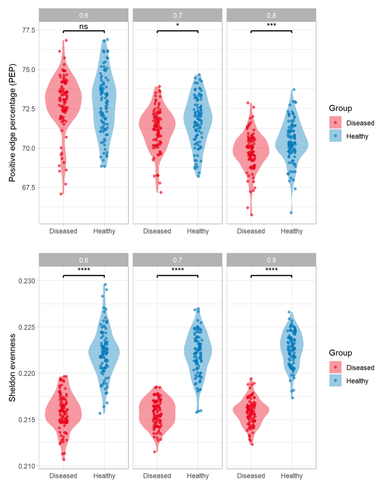

```r
# PEP plot

df_res |>
  ggplot() +
  aes(x = group, y = pep, color = group, fill = group) +
  geom_violin(alpha = 0.4, color = NA) +
  geom_point(position = position_jitter(width = 0.1), alpha = 0.6) +
  scale_color_manual(values = c("Healthy" = "#0078B9", "Diseased" = "#EA0017")) +
  scale_fill_manual(values  = c("Healthy" = "#0078B9", "Diseased" = "#EA0017")) +
  facet_wrap(~ fraction) +
  labs(x = "", y = "Positive edge percentage (PEP)", color = "Group", fill = "Group") +
  stat_compare_means(
    comparisons = list(c("Healthy", "Diseased")),
    method = "wilcox.test",
    label = "p.signif",
    tip.length = 0.01,
    bracket.size = 0.8,
    fontface = "bold"
  ) +

  df_res |>
  ggplot() +
  aes(x = group, y = sheldon, color = group, fill = group) +
  geom_violin(alpha = 0.4, color = NA) +
  geom_point(position = position_jitter(width = 0.1), alpha = 0.6) +
  scale_color_manual(values = c("Healthy" = "#0078B9", "Diseased" = "#EA0017")) +
  scale_fill_manual(values  = c("Healthy" = "#0078B9", "Diseased" = "#EA0017")) +
  facet_wrap(~ fraction) +
  labs(x = "", y = "Sheldon evenness", color = "Group", fill = "Group") +
  stat_compare_means(
    comparisons = list(c("Healthy", "Diseased")),
    method = "wilcox.test",
    label = "p.signif",
    tip.length = 0.01,
    bracket.size = 0.8,
    fontface = "bold"
  ) +

  patchwork::plot_layout(nrow = 2)
```

We will now check if there is any correlation between Sheldon eveness and PEP in the plot below.

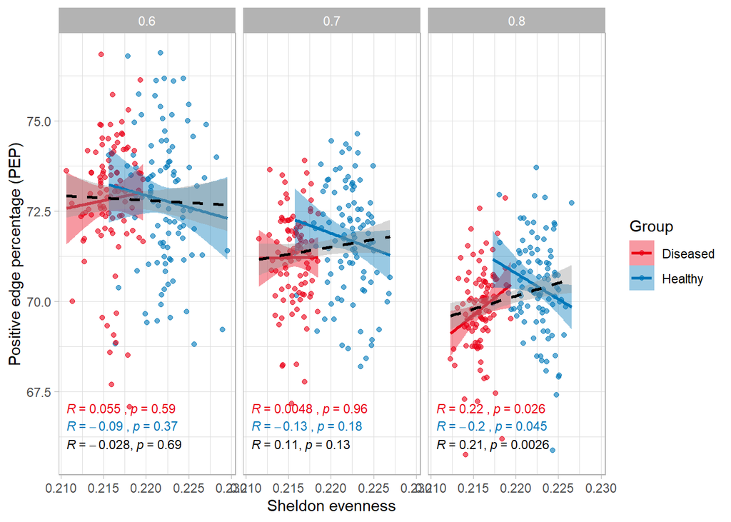

```r
df_res |>
  ggplot() +
  aes(x = sheldon, y = pep, color = group, fill = group) +
  geom_point(alpha = 0.6) +
  geom_smooth(method = "lm", se = TRUE) +
  geom_smooth(aes(x = sheldon, y = pep), method = "lm",
              se = TRUE, inherit.aes = FALSE,
              color = "black", linetype = "dashed") +
  ggpubr::stat_cor(aes(label = after_stat(paste(r.label, p.label, sep = "~`,`~"))),
                   method = "pearson", label.x.npc = "left", label.y.npc = 0.12,
                   size = 3, show.legend = FALSE) +
  ggpubr::stat_cor(aes(x = sheldon, y = pep), method = "pearson",
                   inherit.aes = FALSE, color = "black",
                   label.x.npc = "left", label.y.npc = 0.03,
                   size = 3) +
  scale_color_manual(values = c("Healthy" = "#0078B9", "Diseased" = "#EA0017")) +
  scale_fill_manual(values  = c("Healthy" = "#0078B9", "Diseased" = "#EA0017")) +
  facet_wrap(~ fraction) +
  labs(x = "Sheldon evenness", y = "Positive edge percentage (PEP)", color = "Group", fill = "Group")
```

We will now perform the network analysis on top taxa selected based on their relative abundance. We select a data-driven threshold for relative abundance, which is shown in the plot below. We will keep taxa with a mean relative abundance of at least 0.001 (that is, log10 mean relative abundance of -3). This threshold correspond to the moment when the count starts to drop. Taxa with a mean relative abundance below this threshold will be grouped in a category named “Other”. This is done in the chunk code below.

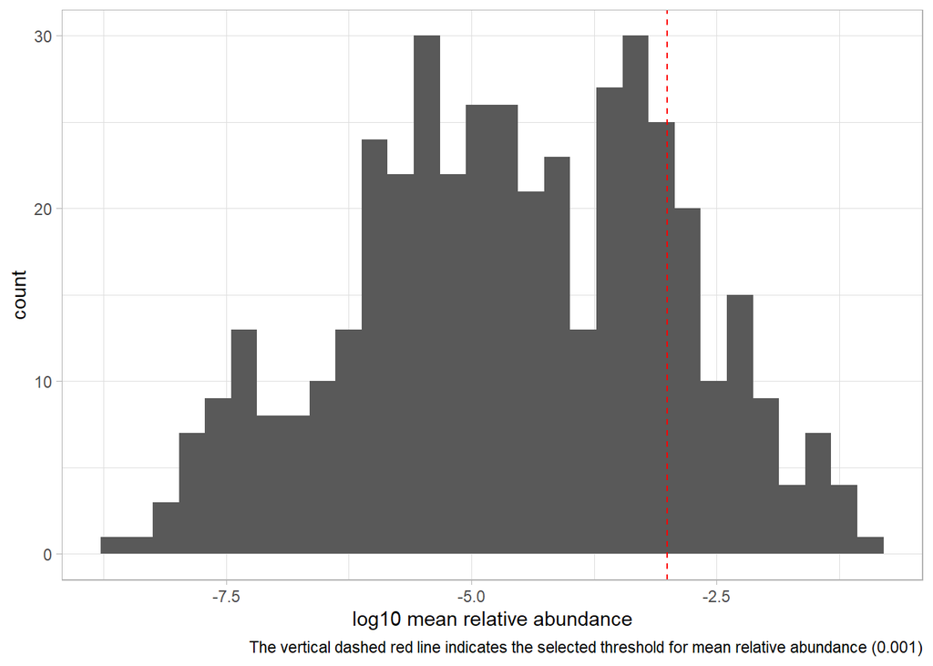

```r
# find data-driven threshold for relative abundance

tmp |>
  group_by(taxon) |>
  summarise(mean_rel_ab = mean(rel_ab)) |>
  arrange(desc(mean_rel_ab)) |>
  ggplot() +
  aes(x = mean_rel_ab |> log10()) +
  geom_histogram(bins = 30) +
  geom_vline(xintercept = -3, linetype = "dashed", color = "red") +
  labs(x = "log10 mean relative abundance", y = "count",
       caption = "The vertical dashed red line indicates the selected threshold for mean relative abundance (0.001)")
```

```r
# filter taxa based on mean relative abundance

tmp_filtered_healthy_top <-
  filter_abundance(tmp_healthy, abundance_threshold = 0.001) |>
  left_join(
    mae[["IBD"]] |> colData() |> as_tibble(rownames = "uid") |> select(uid, pid, visit_num, diagnosis),
    by = join_by(uid)
  )
```

```
Keeping 74 out of 432 taxa with mean abundance >= 0.001
```

```r
tmp_filtered_diseased_top <-
  filter_abundance(tmp_diseased, abundance_threshold = 0.001) |>
  left_join(
    mae[["IBD"]] |> colData() |> as_tibble(rownames = "uid") |> select(uid, pid, visit_num, diagnosis),
    by = join_by(uid)
  )
```

```
Keeping 80 out of 432 taxa with mean abundance >= 0.001
```

We run the FlashWeave network inference on the top taxa for healthy and diseased samples separately, with the following parameters: `n_bootstrap = 100`, `subsample_pcts = c(0.6, 0.7, 0.8)`, and `max_attempts = 120`. This is done in the chunk code below.

```r
healthy_df_top <-
  tmp_filtered_healthy_top |>
  select(uid, taxon, rel_ab) |>
  pivot_wider(names_from = taxon, values_from = rel_ab) |>
  column_to_rownames("uid") |>
  t()

diseased_df_top <-
  tmp_filtered_diseased_top |>
  select(uid, taxon, rel_ab) |>
  pivot_wider(names_from = taxon, values_from = rel_ab) |>
  column_to_rownames("uid") |>
  t()
```

```r
# res_healthy_top <- run_flashweave_bootstrap(healthy_df_top, n_bootstrap = 100, subsample_pcts = c(0.6, 0.7, 0.8), max_attempts = 120, prevalence_threshold = 0)
# res_diseased_top <- run_flashweave_bootstrap(diseased_df_top, n_bootstrap = 100, subsample_pcts = c(0.6, 0.7, 0.8), max_attempts = 120, prevalence_threshold = 0)
#
# saveRDS(res_healthy_top, file = str_c(result_dir(), "/flashweave_res_healthy_top_IBD_20260324.rds"))
# saveRDS(res_diseased_top, file = str_c(result_dir(), "/flashweave_res_diseased_top_IBD_20260324.rds"))
```

We load the results in the chunk code below.

```r
res_healthy_top <- readRDS(file = str_c(result_dir(), "/flashweave_res_healthy_top_IBD_20260324.rds"))
res_diseased_top <- readRDS(file = str_c(result_dir(), "/flashweave_res_diseased_top_IBD_20260324.rds"))
```

The results are obtained in the chunk code below.

```r
df_res_healthy_top <- get_flashweave_results(res_healthy_top)
df_res_diseased_top <- get_flashweave_results(res_diseased_top)

df_res_top <-
  bind_rows(
    df_res_healthy_top |> mutate(group = "Healthy"),
    df_res_diseased_top |> mutate(group = "Diseased")
  )
```

We plot the results below.

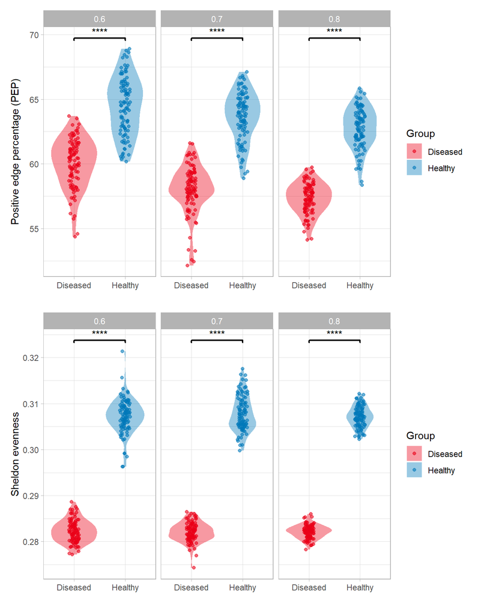

```r
# PEP plot

df_res_top |>
  ggplot() +
  aes(x = group, y = pep, color = group, fill = group) +
  geom_violin(alpha = 0.4, color = NA) +
  geom_point(position = position_jitter(width = 0.1), alpha = 0.6) +
  scale_color_manual(values = c("Healthy" = "#0078B9", "Diseased" = "#EA0017")) +
  scale_fill_manual(values  = c("Healthy" = "#0078B9", "Diseased" = "#EA0017")) +
  facet_wrap(~ fraction) +
  labs(x = "", y = "Positive edge percentage (PEP)", color = "Group", fill = "Group") +
  stat_compare_means(
    comparisons = list(c("Healthy", "Diseased")),
    method = "wilcox.test",
    label = "p.signif",
    tip.length = 0.01,
    bracket.size = 0.8,
    fontface = "bold"
  ) +

df_res_top |>
  ggplot() +
  aes(x = group, y = sheldon, color = group, fill = group) +
  geom_violin(alpha = 0.4, color = NA) +
  geom_point(position = position_jitter(width = 0.1), alpha = 0.6) +
  scale_color_manual(values = c("Healthy" = "#0078B9", "Diseased" = "#EA0017")) +
  scale_fill_manual(values  = c("Healthy" = "#0078B9", "Diseased" = "#EA0017")) +
  facet_wrap(~ fraction) +
  labs(x = "", y = "Sheldon evenness", color = "Group", fill = "Group") +
  stat_compare_means(
    comparisons = list(c("Healthy", "Diseased")),
    method = "wilcox.test",
    label = "p.signif",
    tip.length = 0.01,
    bracket.size = 0.8,
    fontface = "bold"
  ) +

  patchwork::plot_layout(nrow = 2)
```

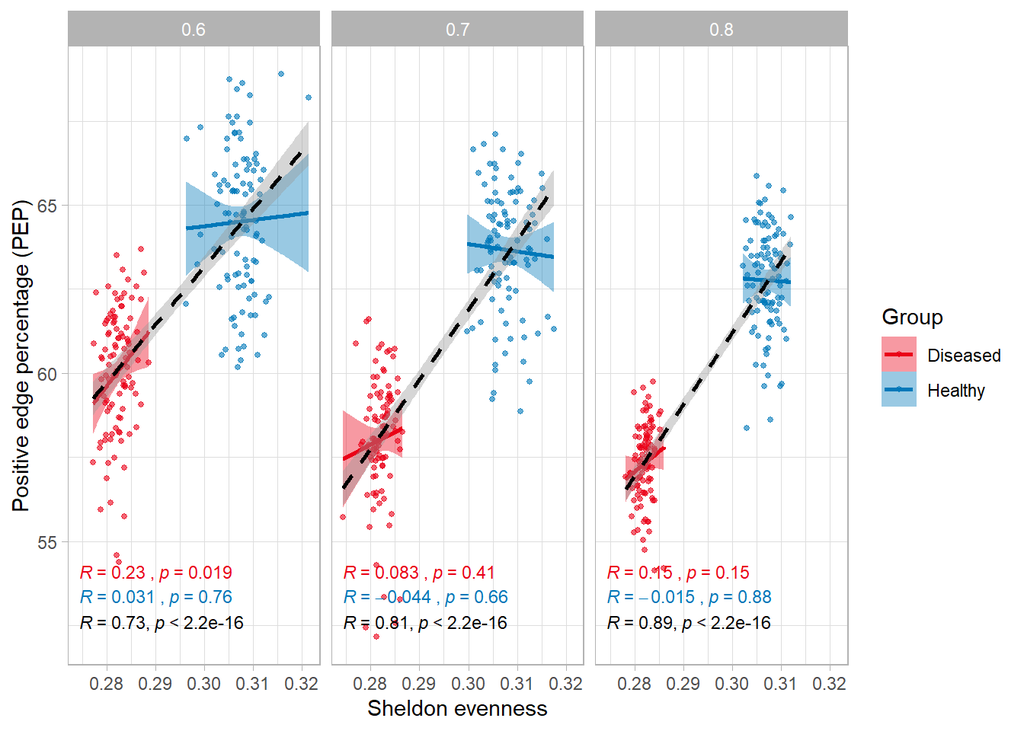

```r
df_res_top |>
  ggplot() +
  aes(x = sheldon, y = pep, color = group, fill = group) +
  geom_point(alpha = 0.6, size = 1) +
  geom_smooth(method = "lm", se = TRUE) +
  geom_smooth(aes(x = sheldon, y = pep), method = "lm",
              se = TRUE, inherit.aes = FALSE,
              color = "black", linetype = "dashed") +
  ggpubr::stat_cor(aes(label = after_stat(paste(r.label, p.label, sep = "~`,`~"))),
                   method = "pearson", label.x.npc = "left", label.y.npc = 0.12,
                   size = 3, show.legend = FALSE) +
  ggpubr::stat_cor(aes(x = sheldon, y = pep), method = "pearson",
                   inherit.aes = FALSE, color = "black",
                   label.x.npc = "left", label.y.npc = 0.03,
                   size = 3) +
  scale_color_manual(values = c("Healthy" = "#0078B9", "Diseased" = "#EA0017")) +
  scale_fill_manual(values  = c("Healthy" = "#0078B9", "Diseased" = "#EA0017")) +
  facet_wrap(~ fraction) +
  labs(x = "Sheldon evenness", y = "Positive edge percentage (PEP)", color = "Group", fill = "Group")
```

## 2.2 IBS cohort

```r
tmp <-
  mae[["IBS"]] |>
  assay() |>
  t() |>
  as.data.frame() |>
  rownames_to_column("uid") |>
  pivot_longer(-uid, names_to = "taxon", values_to = "count") |>
  group_by(uid) |>
  mutate(rel_ab = count/sum(count)) |>
  left_join(
    mae[["IBS"]] |> colData() |> as_tibble(rownames = "uid") |> select(uid, pid, time, cohort),
    by = join_by(uid)
  )
```

```r
tmp_healthy <- tmp |> filter(cohort == "H")
tmp_diseased <- tmp |> filter(cohort == c("C", "D"))
```

```r
# for healthy samples

tmp_filtered_healthy <-
  filter_prevalence(tmp_healthy, prevalence_threshold = 0.05) |>
  left_join(
    mae[["IBS"]] |> colData() |> as_tibble(rownames = "uid") |> select(uid, pid, time, cohort),
    by = join_by(uid)
  )
```

```
Keeping 237 out of 598 taxa with prevalence >= 5 %
```

```r
# for diseased samples

tmp_filtered_diseased <-
  filter_prevalence(tmp_diseased, prevalence_threshold = 0.05) |>
  left_join(
    mae[["IBS"]] |> colData() |> as_tibble(rownames = "uid") |> select(uid, pid, time, cohort),
    by = join_by(uid)
  )
```

```
Keeping 302 out of 598 taxa with prevalence >= 5 %
```

```r
# for healthy samples

healthy_df <-
  tmp_filtered_healthy |>
  select(uid, taxon, rel_ab) |>
  pivot_wider(names_from = taxon, values_from = rel_ab) |>
  column_to_rownames("uid") |>
  t()

# for diseased samples

diseased_df <-
  tmp_filtered_diseased |>
  select(uid, taxon, rel_ab) |>
  pivot_wider(names_from = taxon, values_from = rel_ab) |>
  column_to_rownames("uid") |>
  t()
```

```r
# res_healthy <- run_flashweave_bootstrap(healthy_df, n_bootstrap = 100, subsample_pcts = c(0.8, 0.9), max_attempts = 120)
# res_diseased <- run_flashweave_bootstrap(diseased_df, n_bootstrap = 100, subsample_pcts = c(0.7, 0.8), max_attempts = 120)

# saveRDS(res_healthy, file = str_c(result_dir(), "/flashweave_res_healthy_IBS_20260324.rds"))
# saveRDS(res_diseased, file = str_c(result_dir(), "/flashweave_res_diseased_IBS_20260324.rds"))
```

**Important**

The IBS cohort has only 21 samples for the healthy cohorts, which is not sufficient to run FlashWeave with the selected parameters. A solution can be to modify the max_k parameter, at the cost of inflating the number of indirect edges.

## 2.3 CDI cohort

```r
tmp <-
  mae[["CDI"]] |>
  assay() |>
  t() |>
  as.data.frame() |>
  rownames_to_column("uid") |>
  pivot_longer(-uid, names_to = "taxon", values_to = "count") |>
  group_by(uid) |>
  mutate(rel_ab = count/sum(count)) |>
  left_join(
    mae[["CDI"]] |> colData() |> as_tibble(rownames = "uid") |> select(uid, status, subject_disease_status),
    by = join_by(uid)
  ) |>
  filter(subject_disease_status == "CDI" | subject_disease_status == "CTR")
```

```r
tmp_healthy <- tmp |> filter(subject_disease_status == "CTR")
tmp_diseased <- tmp |> filter(subject_disease_status == "CDI")

# for healthy samples

healthy_df <-
  tmp_healthy |>
  select(uid, taxon, rel_ab) |>
  pivot_wider(names_from = taxon, values_from = rel_ab) |>
  column_to_rownames("uid") |>
  t()

# for diseased samples

diseased_df <-
  tmp_diseased |>
  select(uid, taxon, rel_ab) |>
  pivot_wider(names_from = taxon, values_from = rel_ab) |>
  column_to_rownames("uid") |>
  t()
```

We run the FlashWeave network inference for healthy and diseased samples separately, with the following parameters: `n_bootstrap = 100`, `subsample_pcts = c(0.6, 0.7, 0.8)`, and `max_attempts = 120`. This is done in the chunk code below.

```r
# res_healthy <- run_flashweave_bootstrap(healthy_df, n_bootstrap = 100, subsample_pcts = c(0.6, 0.7, 0.8), max_attempts = 120, prevalence_threshold = 0.05)
# res_diseased <- run_flashweave_bootstrap(diseased_df, n_bootstrap = 100, subsample_pcts = c(0.6, 0.7, 0.8), max_attempts = 120, prevalence_threshold = 0.05)
#
# saveRDS(res_healthy, file = str_c(result_dir(), "/flashweave_res_healthy_CDI_20260324.rds"))
# saveRDS(res_diseased, file = str_c(result_dir(), "/flashweave_res_diseased_CDI_20260324.rds"))
```

We load the results in the chunk code below.

```r
res_healthy <- readRDS(file = str_c(result_dir(), "/flashweave_res_healthy_CDI_20260324.rds"))
res_diseased <- readRDS(file = str_c(result_dir(), "/flashweave_res_diseased_CDI_20260324.rds"))
```

The results are obtained in the chunk code below.

```r
df_res_healthy <- get_flashweave_results(res_healthy)
df_res_diseased <- get_flashweave_results(res_diseased)

df_res <-
  bind_rows(
    df_res_healthy |> mutate(group = "Healthy"),
    df_res_diseased |> mutate(group = "Diseased")
  )
```

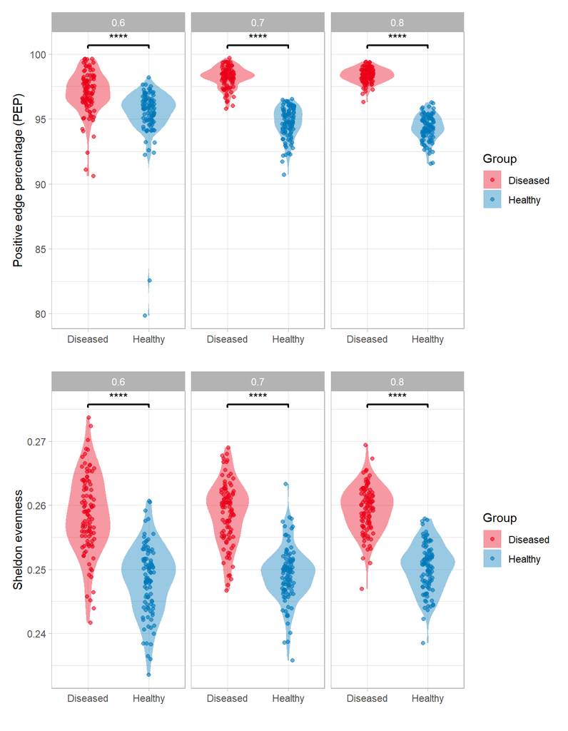

```r
df_res |>
  ggplot() +
  aes(x = group, y = pep, color = group, fill = group) +
  geom_violin(alpha = 0.4, color = NA) +
  geom_point(position = position_jitter(width = 0.1), alpha = 0.6) +
  scale_color_manual(values = c("Healthy" = "#0078B9", "Diseased" = "#EA0017")) +
  scale_fill_manual(values  = c("Healthy" = "#0078B9", "Diseased" = "#EA0017")) +
  facet_wrap(~ fraction) +
  labs(x = "", y = "Positive edge percentage (PEP)", color = "Group", fill = "Group") +
  stat_compare_means(
    comparisons = list(c("Healthy", "Diseased")),
    method = "wilcox.test",
    label = "p.signif",
    tip.length = 0.01,
    bracket.size = 0.8,
    fontface = "bold"
  ) +

df_res |>
  ggplot() +
  aes(x = group, y = sheldon, color = group, fill = group) +
  geom_violin(alpha = 0.4, color = NA) +
  geom_point(position = position_jitter(width = 0.1), alpha = 0.6) +
  scale_color_manual(values = c("Healthy" = "#0078B9", "Diseased" = "#EA0017")) +
  scale_fill_manual(values  = c("Healthy" = "#0078B9", "Diseased" = "#EA0017")) +
  facet_wrap(~ fraction) +
  labs(x = "", y = "Sheldon evenness", color = "Group", fill = "Group") +
  stat_compare_means(
    comparisons = list(c("Healthy", "Diseased")),
    method = "wilcox.test",
    label = "p.signif",
    tip.length = 0.01,
    bracket.size = 0.8,
    fontface = "bold"
  ) +

  patchwork::plot_layout(nrow = 2)
```